# Решающие деревья. Random Forest. Boosting.

Арсланов Н.А.

23 12 2021

### Исходные данные

```r
flats <- read.csv(file = "flats98.csv", header = TRUE, as.is = FALSE)
head(flats)
```

```
##   bal brick   dist floor kitsp livsp metrdist price rooms tel totsp walk
## 1   0     1  7.895     0   9.5  54.0        7    75     3   1  80.0    1
## 2   1     1  6.600     1   8.4  52.0        4   110     3   1  83.0    1
## 3   1     0 16.500     1   8.0  39.5       10    63     3   1  60.8    1
## 4   1     1  1.840     0   8.3  53.0       10   101     3   1  72.0    1
## 5   0     1  1.650     1   7.0  63.0       10   142     3   1  88.0    1
## 6   1     1  1.805     0   8.0  52.0        5   100     3   1  75.0    1
```

Описание признаков:

- TOTSP - площадь квартиры, кв.м.
- price - цена, тыс.долл.
- ROOMS - число комнат
- LIVSP - жилая площадь, кв.м.
- KITSP - площадь кухни, кв.м.
- DIST - расстояние от Центра, км.
- METRDIST - расстояние до ближайшей станции метро, мин.
- WALK - 1, если до квартиры можно пешком дойти до метро, и 0 в противном случае
- BRICK - 1, если дом кирпичный, и 0 в противном случае
- TEL - 1, если есть телефон, и 0 в противном случае
- BAL - 1, если есть балкон, и 0 в противном случае
- FLOOR - 1, если не крайний этаж, и 0 в противном случае

Преобразуем исходные данные. Для начала исключим индивидов, которые содержат пропуски в данных.

```r
flats <- na.omit(flats)
```

Далее превратим признаки rooms, walk, brick, tel, bal и floor в факторы.

```r
flats.orig = flats
catVars = c("rooms","walk","brick","tel","bal","floor")
flats[catVars] = lapply(flats[catVars], as.factor)
```

Затем приведем описательную статистику.

```r
summary(flats)
```

```
##  bal      brick         dist        floor        kitsp           livsp
##  0: 847   0:1916   Min.   : 0.400   0: 898   Min.   : 2.40   Min.   : 10.00
##  1:2150   1:1081   1st Qu.: 5.300   1:2099   1st Qu.: 6.50   1st Qu.: 19.00
##                    Median : 9.600            Median : 8.50   Median : 23.00
##                    Mean   : 9.327            Mean   : 8.31   Mean   : 29.98
##                    3rd Qu.:12.600            3rd Qu.: 9.60   3rd Qu.: 39.00
##                    Max.   :21.875            Max.   :30.00   Max.   :119.00
##     metrdist          price        rooms    tel          totsp        walk
##  Min.   : 0.000   Min.   : 18.00   1:1505   0: 371   Min.   : 18.00   0: 804
##  1st Qu.: 5.000   1st Qu.: 33.00   2: 732   1:2626   1st Qu.: 35.00   1:2193
##  Median :10.000   Median : 42.00   3: 642            Median : 40.00
##  Mean   : 8.657   Mean   : 52.98   4: 118            Mean   : 49.68
##  3rd Qu.:10.000   3rd Qu.: 64.00                     3rd Qu.: 61.00
##  Max.   :25.000   Max.   :490.00                     Max.   :160.00
```

Наконец, построим график pairs, используя brick в качестве категоризующего признака.

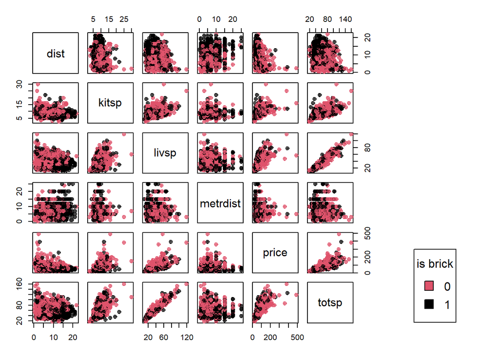

```r
pairs(~ dist + kitsp + livsp + metrdist + price + totsp, data = flats, col = flats$brick, pch = 10, oma=c(3,3,3,15))
par(xpd = TRUE)
legend("bottomright", title = "is brick", fill = unique(flats$brick), legend = c(levels(flats$brick)))
```

По графикам видно, что существуют зависимости между признаками livsp и totsp, kitsp и totsp, price и totsp, price и livsp. Действительно, ведь чем больше общая площадь квартиры, то тем больше будет жилая площадь и площадь кухни. Помимо этого, чем больше площадь, то тем больше цена. Также заметим, что данные в целом можно разделить по признаку brick на две группы.

Прологарифмируем признаки price, totsp и livsp.

```r
flats <- transform(flats, livsp=log(livsp), totsp=log(totsp), price = log(price))
```

Еще раз построим график pairs.

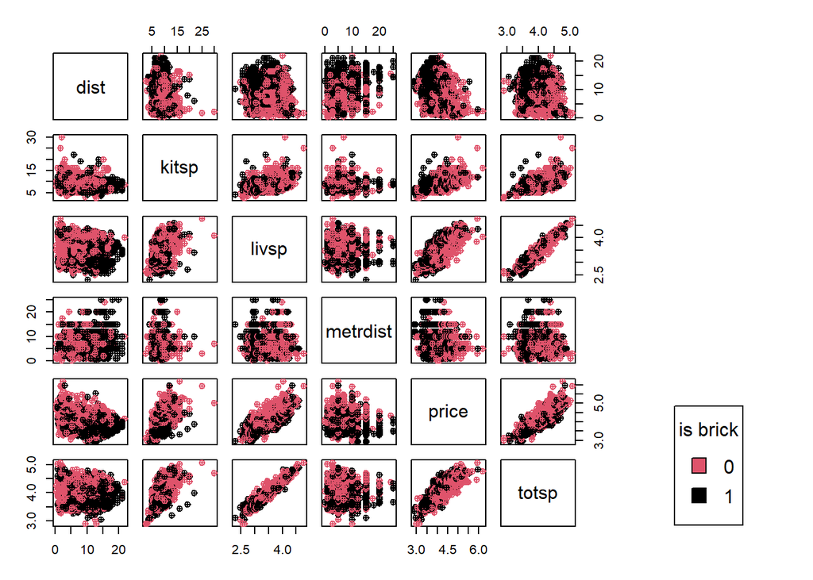

```r
pairs(~ dist + kitsp + livsp + metrdist + price + totsp, data = flats, col = flats$brick, pch = 10, oma=c(3,3,3,15))
par(xpd = TRUE)
legend("bottomright", title = "is brick", fill = unique(flats$brick), legend = c(levels(flats$brick)))
```

### Classification trees

Разделим исходных набор данных на обучающий и тестовый набор в соотношении 80% на 20%.

```r
set.seed(1)
sample <- sample.split(flats, SplitRatio = 0.8)
flats.train <- subset(flats, sample == TRUE)
flats.test <- subset(flats, sample == FALSE)
```

Построим классификационное дерево на обучающем наборе данных. Будем прогнозировать квартиры по признаку brick, используя все остальные переменные. Ниже приведены некоторые сводные статистические данные для дерева классификации, которое было построено на обучающем наборе данных.

```r
tree.flats <- tree(brick ~ ., data = flats.train)
summary(tree.flats)
```

```
##
## Classification tree:
## tree(formula = brick ~ ., data = flats.train)
## Variables actually used in tree construction:
## [1] "price" "kitsp" "dist"
## Number of terminal nodes:  6
## Residual mean deviance:  1.008 = 2259 / 2241
## Misclassification error rate: 0.2354 = 529 / 2247
```

Для построения дерева были взяты признаки price, kitsp и dist. Количество терминальных узлов получилось равным $6$. Для деревьев классификации отклонение задается формулой
$$-2\sum_{m} \sum_{k} n_{mk} \log{\hat{p}_{mk}},$$
где $n_{mk}$ - число наблюдений в m-м терминальном узле, принадлежащих k-му классу, $\hat{p}_{mk}$- доля наблюдений в m-м классе, принадлежащих k-му классу. Остаточное среднее отклонение, которое представляет собой отклонение, деленное на разницу между числом наблюдений и количеством терминальных узлов, составляет $1.008$. Коэффициент ошибки классификации получился равным $0.2354$.

Теперь приведем информацию о каждом полученном узле.

```r
tree.flats
```

```
## node), split, n, deviance, yval, (yprob)
##       * denotes terminal node
##
##  1) root 2247 2947.00 0 ( 0.63596 0.36404 )
##    2) price < 3.95028 1409 1480.00 0 ( 0.78141 0.21859 )
##      4) kitsp < 6.35 412  556.30 0 ( 0.59466 0.40534 ) *
##      5) kitsp > 6.35 997  812.60 0 ( 0.85858 0.14142 )
##       10) dist < 7.955 272  318.40 0 ( 0.72794 0.27206 )
##         20) kitsp < 8.65 154  206.80 0 ( 0.60390 0.39610 ) *
##         21) kitsp > 8.65 118   81.86 0 ( 0.88983 0.11017 ) *
##       11) dist > 7.955 725  446.70 0 ( 0.90759 0.09241 ) *
##    3) price > 3.95028 838 1122.00 1 ( 0.39141 0.60859 )
##      6) dist < 10.5971 605  694.90 1 ( 0.26116 0.73884 ) *
##      7) dist > 10.5971 233  272.00 0 ( 0.72961 0.27039 ) *
```

Здесь можно увидеть названия всех узлов, условия для разделения, количество наблюдений, для которых выполняется то или иное условие, отклонения по ветке, прогнозы по ветке, доли наблюдений в каждой ветке, конечные узлы.

Графически дерево можно представить следующим образом:

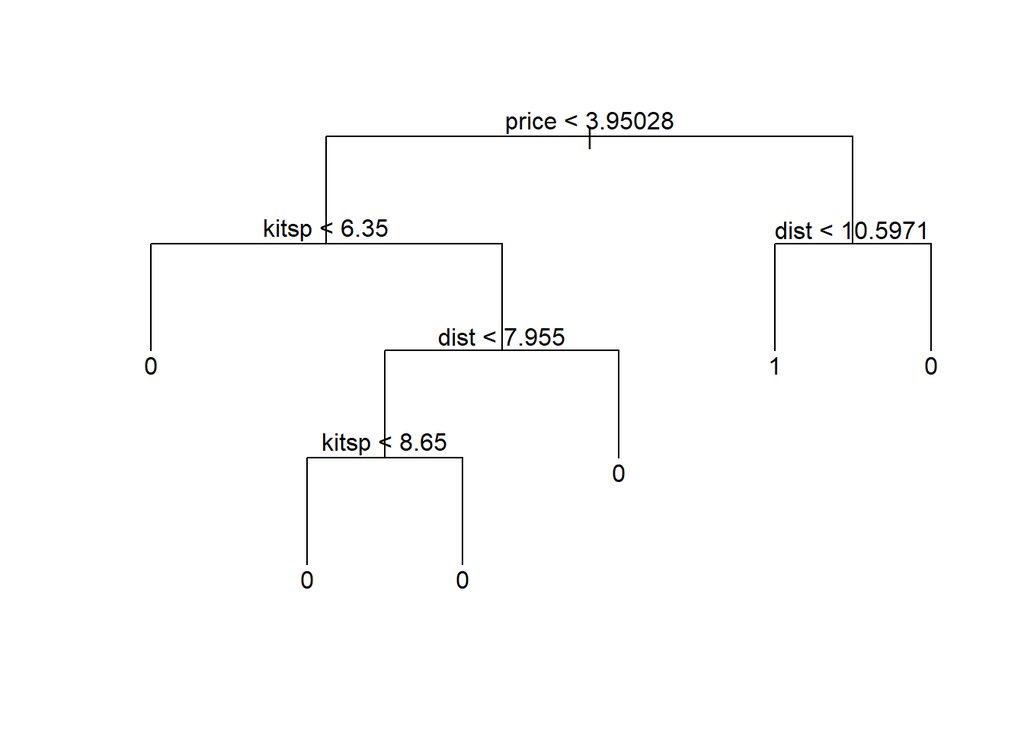

```r
plot(tree.flats, type = "uniform")
text(tree.flats,pretty=0)
```

Можно заметить, что наиболее важным классификационным признаком является price, который на ранних этапах разделения хорошо различает квартиры по признаку brick. После него идут признаки kitsp и dist.

Теперь посмотрим, насколько хорошо работает классификатор. Для этого построим матрицу несоответствия для обучающего набора данных, затем для тестового набора и проанализируем полученные результаты.

Начнем с матрицы несоответствия для тренировочного набора данных.

```r
tree.pred=predict(tree.flats,flats.train,type="class")
cmClassTree = table(factor(tree.pred), flats.train$brick)
cmClassTree
```

```
##
##        0    1
##   0 1271  371
##   1  158  447
```

Найдем вероятность правильной классификации.

```r
mean(flats.train$brick == tree.pred)
```

```
## [1] 0.764575
```

Также определим вероятность попадания в нужный класс.

```r
diag(prop.table(cmClassTree, 2))
```

```
##         0         1
## 0.8894332 0.5464548
```

Можно заметить, что дерево на тренировочном наборе данных смогло правильно классифицировать квартиры, находящиеся не в кирпичных домах, с вероятностью примерно $88.94$%, а квартиры, которые, наоборот, находятся в кирпичных домах, с вероятностью $54.64$%. Общая вероятность правильной классификации составляет $76.45$%.

Теперь построим матрицу несоответствия для тестового набора данных.

```r
tree.pred=predict(tree.flats,flats.test,type="class")
cmClassTree = table(factor(tree.pred), flats.test$brick)
cmClassTree
```

```
##
##       0   1
##   0 438 128
##   1  49 135
```

Найдем вероятность правильной классификации.

```r
mean(flats.test$brick == tree.pred)
```

```
## [1] 0.764
```

Также определим вероятность попадания в нужный класс.

```r
diag(prop.table(cmClassTree, 2))
```

```
##        0        1
## 0.899384 0.513308
```

Заметим, что дерево на тестовом наборе данных смогло правильно классифицировать квартиры, находящиеся не в кирпичных домах, с вероятностью примерно $89.93$%, а квартиры, которые, наоборот, находятся в кирпичных домах, с вероятностью $51.33$%. Общая вероятность правильной классификации составляет $76.4$%.

Теперь попробуем обрезать дерево для улучшения результатов. Для этого сначала воспользуемся кросс-валидацией для определения оптимального размера дерева. График размера дерева и ошибок классификации представлен ниже.

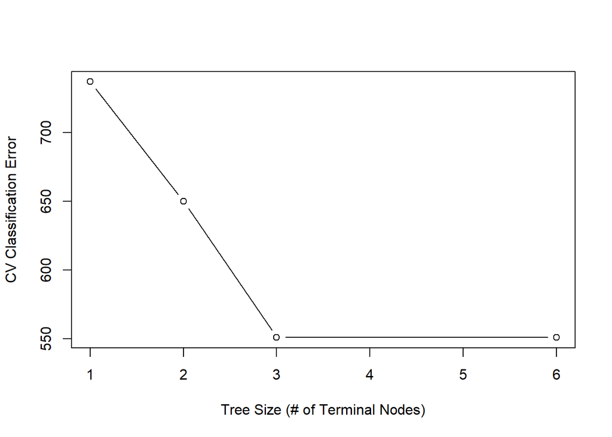

```r
set.seed(1)
cv.flats =cv.tree(tree.flats, FUN=prune.misclass, K = 10)
plot(cv.flats$size,cv.flats$dev,type="b", xlab = "Tree Size (# of Terminal Nodes)",
     ylab="CV Classification Error")
```

Можно заметить, что величина ошибки классификации принимает наименьшее значение тогда, когда количество терминальных узлов равно 3-м и более. В рассмотренном выше дереве классификации использовалось 6 терминальных узлов. Посмотрим, какие результаты получатся при 3 терминальных узлах.

```r
prune.flats=prune.tree(tree.flats,best=3)
summary(prune.flats)
```

```
##
## Classification tree:
## snip.tree(tree = tree.flats, nodes = 2L)
## Variables actually used in tree construction:
## [1] "price" "dist"
## Number of terminal nodes:  3
## Residual mean deviance:  1.09 = 2447 / 2244
## Misclassification error rate: 0.2354 = 529 / 2247
```

Информация об узлах в “обрезанном” дереве.

```r
prune.flats
```

```
## node), split, n, deviance, yval, (yprob)
##       * denotes terminal node
##
## 1) root 2247 2947.0 0 ( 0.6360 0.3640 )
##   2) price < 3.95028 1409 1480.0 0 ( 0.7814 0.2186 ) *
##   3) price > 3.95028 838 1122.0 1 ( 0.3914 0.6086 )
##     6) dist < 10.5971 605  694.9 1 ( 0.2612 0.7388 ) *
##     7) dist > 10.5971 233  272.0 0 ( 0.7296 0.2704 ) *
```

График “обрезанного” дерева.

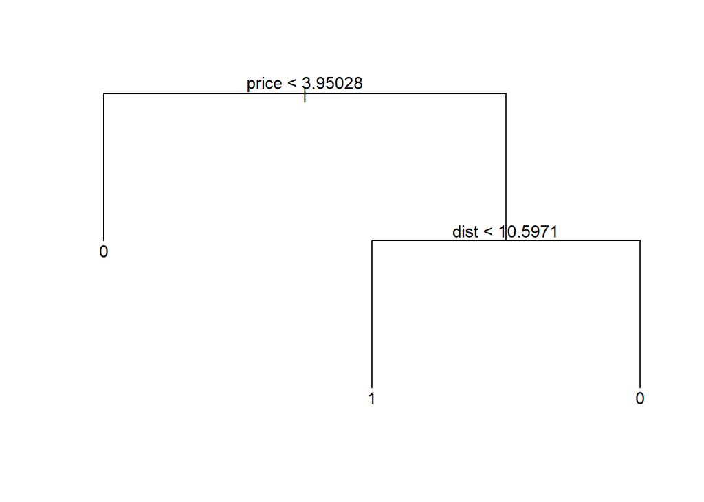

```r
plot(prune.flats, type = "uniform")
text(prune.flats,pretty=0)
```

По дереву видно, что наиболее важными признаками для классификации являются price и dist.

Построим матрицу несоответствия по тренировочному набору данных.

```r
tree.pred=predict(prune.flats,flats.train,type="class")
cmClassTree = table(factor(tree.pred), flats.train$brick)
cmClassTree
```

```
##
##        0    1
##   0 1271  371
##   1  158  447
```

Найдем вероятность правильной классификации.

```r
mean(flats.train$brick == tree.pred)
```

```
## [1] 0.764575
```

Также определим вероятность попадания в нужный класс.

```r
diag(prop.table(cmClassTree, 2))
```

```
##         0         1
## 0.8894332 0.5464548
```

Заметим, что “обрезанное” дерево на тренировочном наборе данных смогло правильно классифицировать квартиры, находящиеся не в кирпичных домах, с вероятностью примерно $88.94$%, а квартиры, которые, наоборот, находятся в кирпичных домах, с вероятностью $54.64$%. Общая вероятность правильной классификации составляет $76.45$%.

Построим матрицу несоответствия по тестовым данным.

```r
tree.pred=predict(prune.flats,flats.test,type="class")
cmClassTree = table(factor(tree.pred), flats.test$brick)
cmClassTree
```

```
##
##       0   1
##   0 438 128
##   1  49 135
```

Найдем вероятность правильной классификации.

```r
mean(flats.test$brick == tree.pred)
```

```
## [1] 0.764
```

Также определим вероятность попадания в нужный класс.

```r
diag(prop.table(cmClassTree, 2))
```

```
##        0        1
## 0.899384 0.513308
```

Заметим, что “обрезанное” дерево на тестовом наборе данных смогло правильно классифицировать квартиры, находящиеся не в кирпичных домах, с вероятностью примерно $89.93$%, а квартиры, которые, наоборот, находятся в кирпичных домах, с вероятностью $51.33$%. Общая вероятность правильной классификации составляет $76.4$%.

Таким образом, мы уменьшили число используемых терминальных узлов в дереве без потери точности классификации.

### Random Forests for classification

Теперь попробуем классифицировать исходных набор данных, используя случайный лес и бэггинг - частный случай случайного леса, при котором m = p, где m - используемое число признаков, а p - общее число предикторов. В каждом случае обучим модель на тренировочной выборке, затем сделаем прогнозы и построим матрицы несоответствия.

Начнем с бэггинга.

Для начала определим оптимальное количество деревьев в случайном лесу.

```r
set.seed(1)

err_train <- vector()
err_test <- vector()
n_estimators <- vector()

min_estimators = 1
max_estimators = 100

for (n in min_estimators:max_estimators){
        rf_clf <- randomForest(brick ~ ., data = flats.train, ntree=n, mtry=11, importance =TRUE)
        yhat.flats.train<-predict(rf_clf, flats.train,type="class")
        yhat.flats.test<-predict(rf_clf, flats.test,type="class")
        err_train <- c(err_train,(1 - mean(flats.train$brick == yhat.flats.train)))
        err_test <- c(err_test,(1 - mean(flats.test$brick == yhat.flats.test)))
        n_estimators <- c(n_estimators, n)
}
errors <- data.frame(n_estimators, err_train, err_test)
```

Построим график зависимости величины ошибки от количества используемых деревьев в модели.

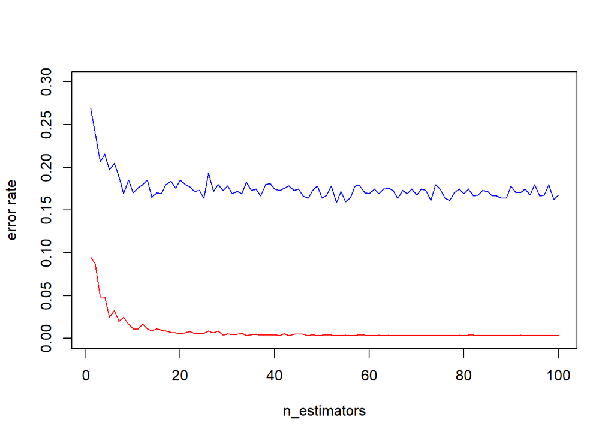

```r
plot(n_estimators, err_train, type="l",  ylim = c(0,0.3), xlab = "n_estimators", ylab="error rate", col="red")
lines(n_estimators, err_test, type="l", col="blue")
```

Оптимальным числом деревьев можно считать 16, поскольку при большем количестве ошибка практически не изменяется на тренировочном наборе данных.

```r
set.seed(1)
rf.flats<-randomForest(brick ~ ., data = flats.train, ntree=16, mtry=11, importance =TRUE)
rf.flats
```

```
##
## Call:
##  randomForest(formula = brick ~ ., data = flats.train, ntree = 16,      mtry = 11, importance = TRUE)
##                Type of random forest: classification
##                      Number of trees: 16
## No. of variables tried at each split: 11
##
##         OOB estimate of  error rate: 20.18%
## Confusion matrix:
##      0   1 class.error
## 0 1218 210   0.1470588
## 1  243 574   0.2974296
```

Матрица несоответствия на тестовом наборе данных.

```r
yhat.flats<-predict(rf.flats, flats.test,type="class")
cmClassRandomForest = table(factor(yhat.flats), flats.test$brick)
cmClassRandomForest
```

```
##
##       0   1
##   0 431  74
##   1  56 189
```

Найдем вероятность правильной классификации.

```r
mean(flats.test$brick == yhat.flats)
```

```
## [1] 0.8266667
```

Также определим вероятность попадания в нужный класс.

```r
diag(prop.table(cmClassRandomForest, 2))
```

```
##         0         1
## 0.8850103 0.7186312
```

Заметим, что бэггинг на тестовом наборе данных смог правильно классифицировать квартиры, находящиеся не в кирпичных домах, с вероятностью примерно $88.5$%, а квартиры, которые, наоборот, находятся в кирпичных домах, с вероятностью $71.86$%. Общая вероятность правильной классификации составляет $82.66$%.

Теперь перейдем к случайному лесу. Отметим, что при построении случайного леса деревьев классификации по умолчанию используется $\sqrt{p}$ признаков.

Определим оптимальное число деревьев в случайном лесу.

```r
set.seed(1)

err_train <- vector()
err_test <- vector()
n_estimators <- vector()

min_estimators = 1
max_estimators = 100

for (n in min_estimators:max_estimators){
        rf_clf <- randomForest(brick ~ ., data = flats.train, ntree=n, importance =TRUE)
        yhat.flats.train<-predict(rf_clf, flats.train,type="class")
        yhat.flats.test<-predict(rf_clf, flats.test,type="class")
        err_train <- c(err_train,(1 - mean(flats.train$brick == yhat.flats.train)))
        err_test <- c(err_test,(1 - mean(flats.test$brick == yhat.flats.test)))
        n_estimators <- c(n_estimators, n)
}
errors <- data.frame(n_estimators, err_train, err_test)
```

Построим график зависимости величины ошибки от количества используемых деревьев в модели.

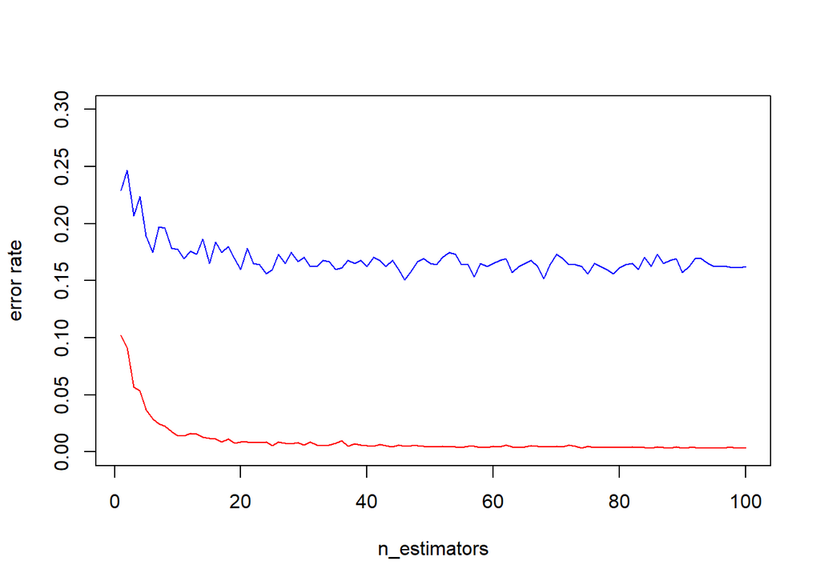

```r
plot(n_estimators, err_train, type="l",  ylim = c(0,0.3), xlab = "n_estimators", ylab="error rate", col="red")
lines(n_estimators, err_test, type="l", col="blue")
```

Оптимальным числом деревьев можно считать 20, поскольку при большем количестве ошибка практически не изменяется на тренировочном наборе данных.

```r
set.seed(1)
rf.flats<-randomForest(brick ~ ., data = flats.train, ntree=20, importance =TRUE)
rf.flats
```

```
##
## Call:
##  randomForest(formula = brick ~ ., data = flats.train, ntree = 20,      importance = TRUE)
##                Type of random forest: classification
##                      Number of trees: 20
## No. of variables tried at each split: 3
##
##         OOB estimate of  error rate: 21.05%
## Confusion matrix:
##      0   1 class.error
## 0 1204 225   0.1574528
## 1  248 570   0.3031785
```

Матрица несоответствия на тестовом наборе данных.

```r
yhat.flats<-predict(rf.flats, flats.test,type="class")
cmClassRandomForest = table(factor(yhat.flats), flats.test$brick)
cmClassRandomForest
```

```
##
##       0   1
##   0 431  80
##   1  56 183
```

Найдем вероятность правильной классификации.

```r
mean(flats.test$brick == yhat.flats)
```

```
## [1] 0.8186667
```

Также определим вероятность попадания в нужный класс.

```r
diag(prop.table(cmClassRandomForest, 2))
```

```
##         0         1
## 0.8850103 0.6958175
```

Заметим, что соучайный лес на тестовом наборе данных смог правильно классифицировать квартиры, находящиеся не в кирпичных домах, с вероятностью примерно $88.5$%, а квартиры, которые, наоборот, находятся в кирпичных домах, с вероятностью $69.58$%. Общая вероятность правильной классификации составляет $81.86$%.

Наконец, определим важность каждого признака.

```r
importance(rf.flats)
```

```
##                   0          1 MeanDecreaseAccuracy MeanDecreaseGini
## bal       2.9479325  2.6305785            4.0524469         19.96758
## dist     14.0950799 16.2755837           19.5941315        204.77306
## floor     1.0096521  2.4876722            2.3678973         17.87148
## kitsp     6.5828097  7.6536317            9.9481941        128.70055
## livsp     6.4325355  4.6686040            8.8755002        142.89953
## metrdist  4.7428561  5.7012322            7.7588510         58.43046
## price     7.6861339  5.0738034           11.5238564        207.54800
## rooms     3.7234526  0.6617831            4.5811883         34.60887
## tel       0.1020698  0.6979852            0.5194641         11.73633
## totsp     8.5552951  3.6974873           10.0354001        166.31332
## walk      3.1057149  2.2424442            4.0374118         17.30127
```

- MeanDecreaseAccuracy- cреднее снижение точности (коэффициент ошибок для классификации).
- MeanDecreaseGini- cреднее падение индекса Джини. При каждом ветвлении на дереве падает индекс Джини. Для каждой переменной можно посчитать суммарное падение индекса Джини, вызванное ветвлениями на базе этой переменной. Посчитав среднее падение Джини по всем деревьям получим меру важности.

### Regression Trees

Перейдем к построению регрессионных деревьев. Будем прогнозировать price, используя все остальные переменные. Ниже приведены некоторые сводные статистические данные для регрессионного дерева, которое было построено на обучающем наборе данных.

```r
reg.tree.flats <- tree(price ~ ., data = flats.train)
summary(reg.tree.flats)
```

```
##
## Regression tree:
## tree(formula = price ~ ., data = flats.train)
## Variables actually used in tree construction:
## [1] "totsp" "dist"  "brick"
## Number of terminal nodes:  8
## Residual mean deviance:  0.04304 = 96.37 / 2239
## Distribution of residuals:
##     Min.  1st Qu.   Median     Mean  3rd Qu.     Max.
## -0.75410 -0.12410 -0.02171  0.00000  0.11230  1.19500
```

Посмотрим на структуру узлов полученного регрессионного дерева.

```r
reg.tree.flats
```

```
## node), split, n, deviance, yval
##       * denotes terminal node
##
##  1) root 2247 451.300 3.856
##    2) totsp < 3.90192 1359  60.350 3.572
##      4) totsp < 3.54241 479  11.780 3.435 *
##      5) totsp > 3.54241 880  34.670 3.647
##       10) dist < 6.04 234  12.620 3.799 *
##       11) dist > 6.04 646  14.690 3.592 *
##    3) totsp > 3.90192 888 113.800 4.290
##      6) totsp < 4.22244 480  28.410 4.109
##       12) brick: 0 257   9.342 4.015 *
##       13) brick: 1 223  14.120 4.218 *
##      7) totsp > 4.22244 408  51.230 4.503
##       14) totsp < 4.68674 386  35.100 4.462
##         28) dist < 4.425 78   8.142 4.691 *
##         29) dist > 4.425 308  21.830 4.404 *
##       15) totsp > 4.68674 22   3.844 5.230 *
```

Построим регрессионное дерево.

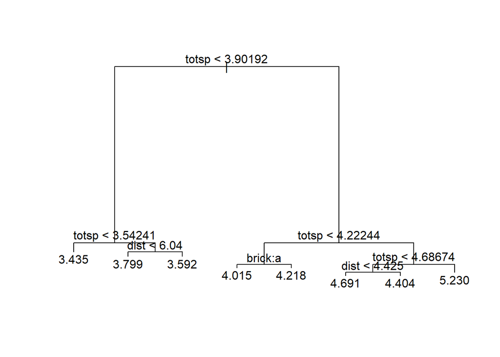

```r
plot(reg.tree.flats)
text(reg.tree.flats)
```

Теперь попробуем "“обрезать дерево” для улучшения результатов. Для этого сначала определим оптимальный размер дерева. Ниже представлен соответствующий график.

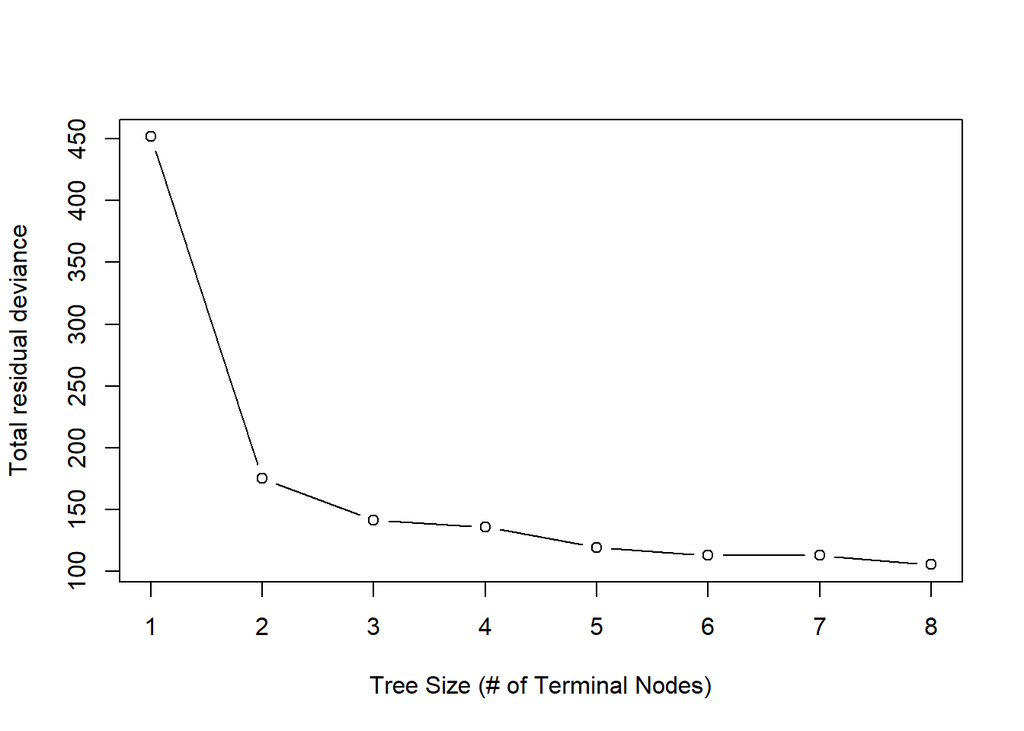

```r
set.seed(1)
cv.reg.flats =cv.tree(reg.tree.flats, K = 10)
plot(cv.reg.flats$size,cv.reg.flats$dev,type="b", xlab = "Tree Size (# of Terminal Nodes)",
     ylab="Total residual deviance")
```

Можно заметить, что наименьшая величина Total residual deviance достигается тогда, когда количество терминальных узлов равно 8. В рассмотренном выше регрессионном дереве как раз оно и использовалось. Поэтому можно не “обрезать” дерево.

Теперь сделаем прогнозы на тестовом наборе данных и рассчитаем MSE.

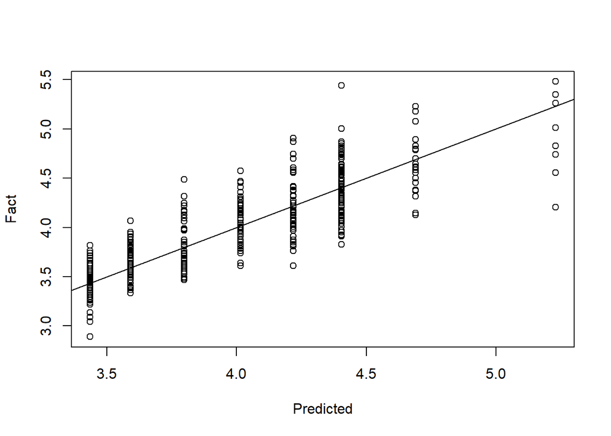

```r
reg.tree.pred=predict(reg.tree.flats,flats.test)
plot(reg.tree.pred, flats.test$price, xlab="Predicted", ylab="Fact")
abline(0,1)
```

MSE для тестового набора данных.

```r
MSE <- mean((reg.tree.pred-flats.test$price)^2)
MSE
```

```
## [1] 0.04240807
```

Корень из MSE.

```r
MSEsqrt <- sqrt(MSE)
MSEsqrt
```

```
## [1] 0.2059322
```

Таким образом, MSE для тестового набора, получился равным $0.04240807$. Квадратный корень из MSE равен $0.2059322$.

### Random Forests for regression

Теперь попробуем построить регрессию, используя случайный лес и бэггинг. Для каждого из вариантов обучим модель на тренировочной выборке и сделаем прогнозы.

Начнем с бэггинга.

Для начала определим оптимальное число деревьев.

```r
set.seed(1)

mse_train <- vector()
mse_test <- vector()
n_estimators <- vector()

min_estimators = 1
max_estimators = 100

for (n in min_estimators:max_estimators){
        rf_reg <- randomForest(price ~ ., data = flats.train, ntree=n, mtry=11, importance =TRUE)
        yhat.flats.train<-predict(rf_reg, flats.train)
        yhat.flats.test<-predict(rf_reg, flats.test)
        mse_train <- c(mse_train,mean((yhat.flats.train-flats.train$price)^2))
        mse_test <- c(mse_test,mean((yhat.flats.test-flats.test$price)^2))
        n_estimators <- c(n_estimators, n)
}
errors_reg <- data.frame(n_estimators, mse_train, mse_test)
```

Построим график зависимости MSE от количества используемых деревьев в модели.

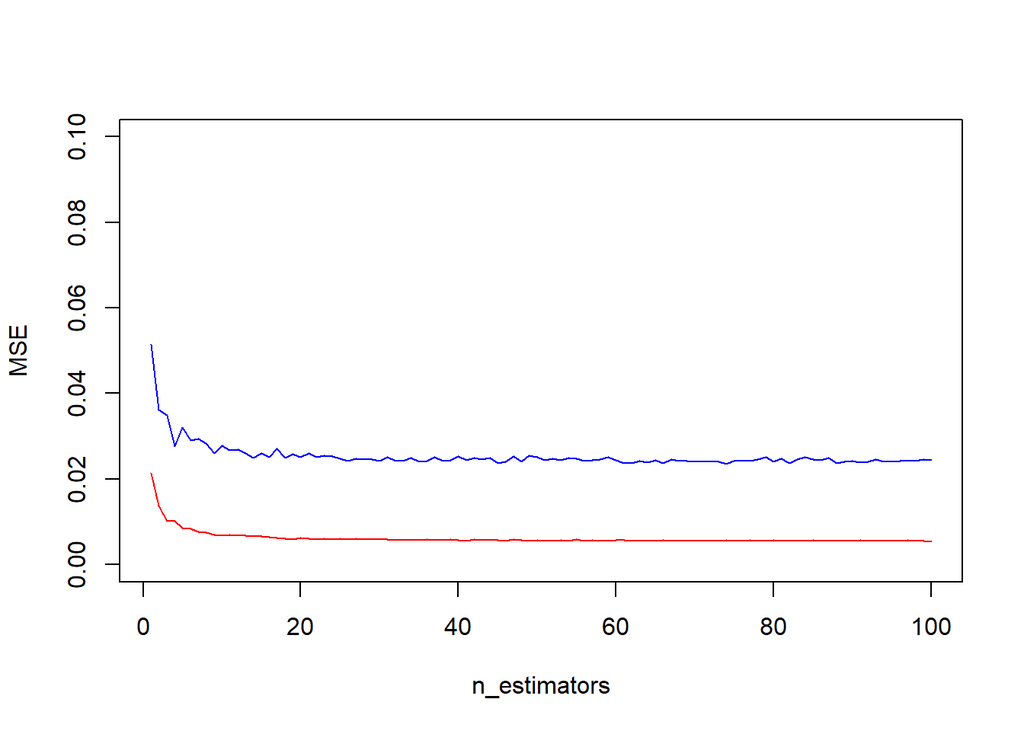

```r
plot(n_estimators, mse_train, type="l",  ylim = c(0,0.1), xlab = "n_estimators", ylab="MSE", col="red")
lines(n_estimators, mse_test, type="l", col="blue")
```

Оптимальным числом деревьев можно считать 9, поскольку при большем количестве ошибка практически не изменяется на тренировочном наборе данных.

```r
set.seed(1)
reg.rf.flats<-randomForest(price ~ ., data = flats.train, ntree=9, mtry=11, importance =TRUE)
reg.rf.flats
```

```
##
## Call:
##  randomForest(formula = price ~ ., data = flats.train, ntree = 9,      mtry = 11, importance = TRUE)
##                Type of random forest: regression
##                      Number of trees: 9
## No. of variables tried at each split: 11
##
##           Mean of squared residuals: 0.03772897
##                     % Var explained: 81.22
```

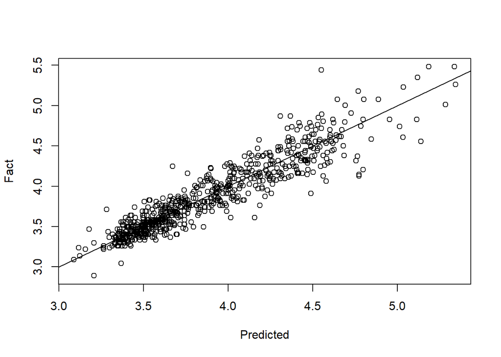

```r
reg.rf.pred=predict(reg.rf.flats,flats.test)
plot(reg.rf.pred, flats.test$price, xlab="Predicted", ylab="Fact")
abline(0,1)
```

MSE для тестового набора данных.

```r
MSE <- mean((reg.rf.pred-flats.test$price)^2)
MSE
```

```
## [1] 0.02548316
```

Корень из MSE.

```r
MSEsqrt <- sqrt(MSE)
MSEsqrt
```

```
## [1] 0.1596345
```

Таким образом, MSE для тестового набора, получился равным $0.02548316$. Квадратный корень из MSE равен $0.1596345$.

Наконец, определим важность каждого признака.

```r
importance(reg.rf.flats)
```

```
##            %IncMSE IncNodePurity
## bal       3.680329      2.617409
## brick     8.464288      8.954188
## dist     13.413165     37.016456
## floor     3.032294      3.477524
## kitsp     5.577371     15.079254
## livsp     4.969618     10.718882
## metrdist  3.262209      7.707471
## rooms     3.127116      1.468665
## tel       2.877406      2.570456
## totsp    33.617008    352.941940
## walk      5.016194      5.715359
```

- %IncMSE- среднее снижении точности прогнозов (оценивается MSE предсказаний).
- IncNodePurity - мера среднего увеличения “чистоты узла” дерева (node purity) в результате разбиения данных по соответствующей переменной. В случае деревьев регрессии чистота узлов измеряется RSS обучающего набора.

Графики этих мер важности:

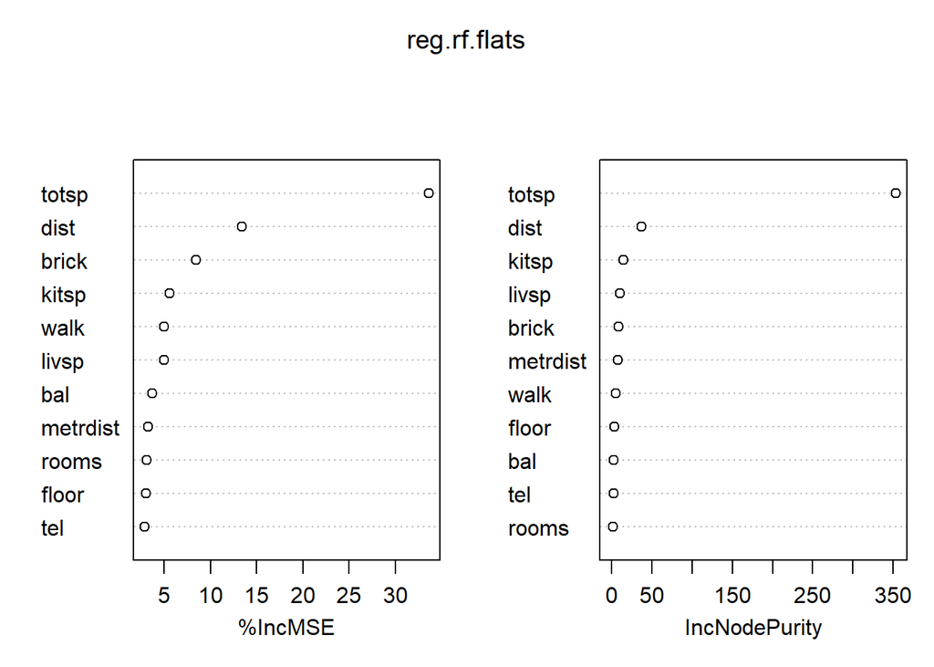

```r
varImpPlot (reg.rf.flats)
```

Теперь построим случайный лес. Отметим, что по умолчанию здесь используется $\frac{p}{3}$ переменных при построении случайного леса деревьев регрессии.

Для начала определим оптимальное число деревьев.

```r
set.seed(1)

mse_train <- vector()
mse_test <- vector()
n_estimators <- vector()

min_estimators = 1
max_estimators = 100

for (n in min_estimators:max_estimators){
        rf_reg <- randomForest(price ~ ., data = flats.train, ntree=n, importance =TRUE)
        yhat.flats.train<-predict(rf_reg, flats.train)
        yhat.flats.test<-predict(rf_reg, flats.test)
        mse_train <- c(mse_train,mean((yhat.flats.train-flats.train$price)^2))
        mse_test <- c(mse_test,mean((yhat.flats.test-flats.test$price)^2))
        n_estimators <- c(n_estimators, n)
}
errors_reg <- data.frame(n_estimators, mse_train, mse_test)
```

Построим график зависимости MSE от количества используемых деревьев в модели.

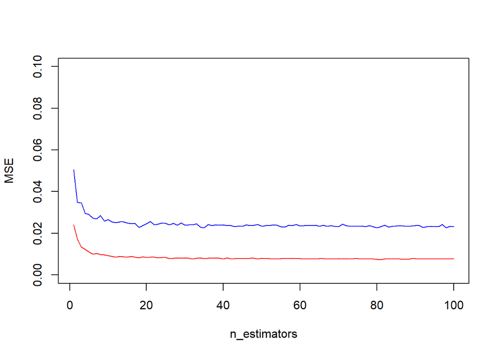

```r
plot(n_estimators, mse_train, type="l",  ylim = c(0,0.1), xlab = "n_estimators", ylab="MSE", col="red")
lines(n_estimators, mse_test, type="l", col="blue")
```

Оптимальным числом деревьев можно считать 7, поскольку при большем количестве ошибка практически не изменяется на тренировочном наборе данных.

```r
set.seed(1)
reg.rf.flats<-randomForest(price ~ ., data = flats.train, ntree=7, importance =TRUE)
reg.rf.flats
```

```
##
## Call:
##  randomForest(formula = price ~ ., data = flats.train, ntree = 7,      importance = TRUE)
##                Type of random forest: regression
##                      Number of trees: 7
## No. of variables tried at each split: 3
##
##           Mean of squared residuals: 0.03812465
##                     % Var explained: 81.02
```

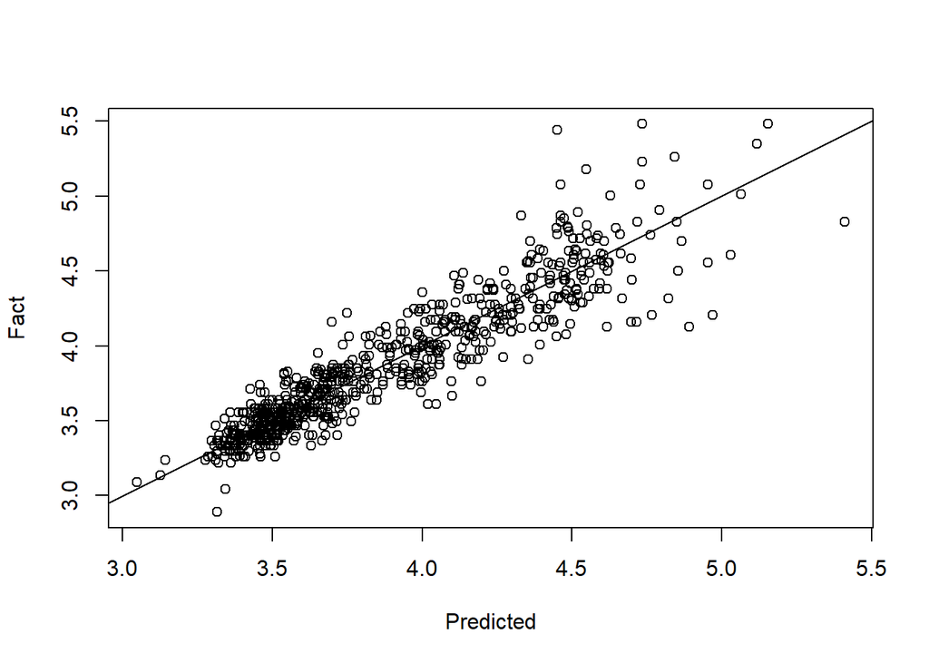

```r
reg.rf.pred=predict(reg.rf.flats,flats.test)
plot(reg.rf.pred, flats.test$price, xlab="Predicted", ylab="Fact")
abline(0,1)
```

MSE для тестового набора данных.

```r
MSE <- mean((reg.rf.pred-flats.test$price)^2)
MSE
```

```
## [1] 0.02869584
```

Корень из MSE.

```r
MSEsqrt <- sqrt(MSE)
MSEsqrt
```

```
## [1] 0.1693985
```

Таким образом, MSE для тестового набора, получился равным $0.02869584$. Квадратный корень из MSE равен $0.1693985$.

Наконец, определим важность каждого признака.

```r
importance(reg.rf.flats)
```

```
##           %IncMSE IncNodePurity
## bal      4.351097      3.730475
## brick    4.301976     14.897145
## dist     9.990120     29.331874
## floor    3.595599      3.203684
## kitsp    5.931342     41.351149
## livsp    2.823295     68.775619
## metrdist 2.166564      8.541822
## rooms    3.387966     14.045045
## tel      2.939881      2.437986
## totsp    6.508304    245.677956
## walk     4.410862      4.936516
```

Графики этих мер важности:

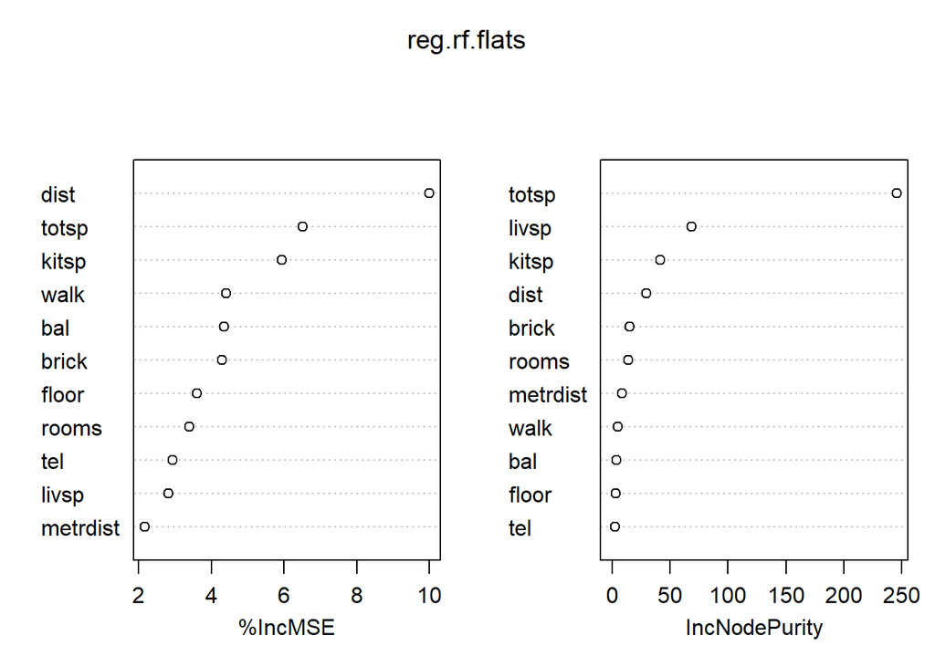

```r
varImpPlot (reg.rf.flats)
```

### Boosting

Построим boosting модель на обучающем наборе данных, где признак “brick” - зависимая переменная, а все остальное - регрессоры.

```r
flats.train.logical <- flats.train
flats.test.logical <- flats.test
```

Определим оптимальное число деревьев.

```r
set.seed(1)

err_train <- vector()
err_test <- vector()
n_estimators <- vector()

min_estimators = 1
max_estimators = 500

for (n in min_estimators:max_estimators){
        boost.flats <- gbm(brick ~ ., data = flats.train.logical, distribution = "multinomial", n.trees = n, shrinkage = 0.01)
        yhat.flats.train<-predict.gbm(boost.flats, flats.train.logical)
        labels_train = colnames( yhat.flats.train)[apply( yhat.flats.train, 1, which.max)]
        labels_train = as.factor(labels_train)
        err_train <- c(err_train,(1 - mean(flats.train.logical$brick == labels_train)))
        n_estimators <- c(n_estimators, n)
}
errors <- data.frame(n_estimators, err_train)
```

Построим график зависимости величины ошибки от количества используемых деревьев в модели.

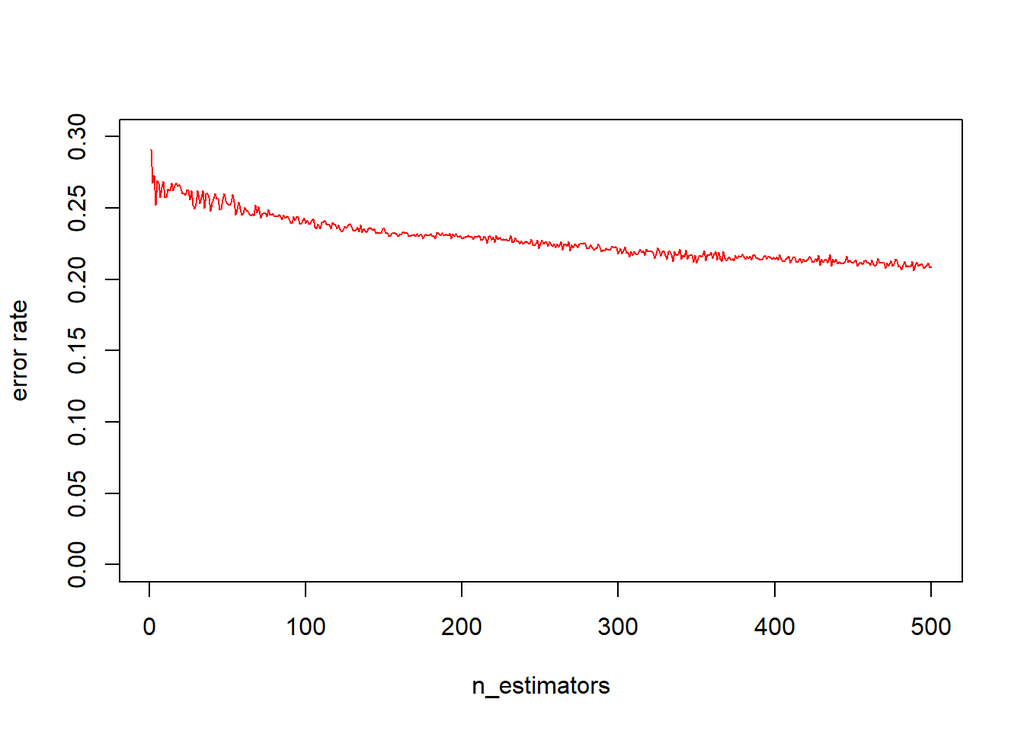

```r
plot(n_estimators, err_train, type="l",  ylim = c(0,0.3), xlab = "n_estimators", ylab="error rate", col="red")
```

Оптимальным числом деревьев можно считать 360, поскольку при большем количестве ошибка практически не изменяется на тренировочном наборе данных.

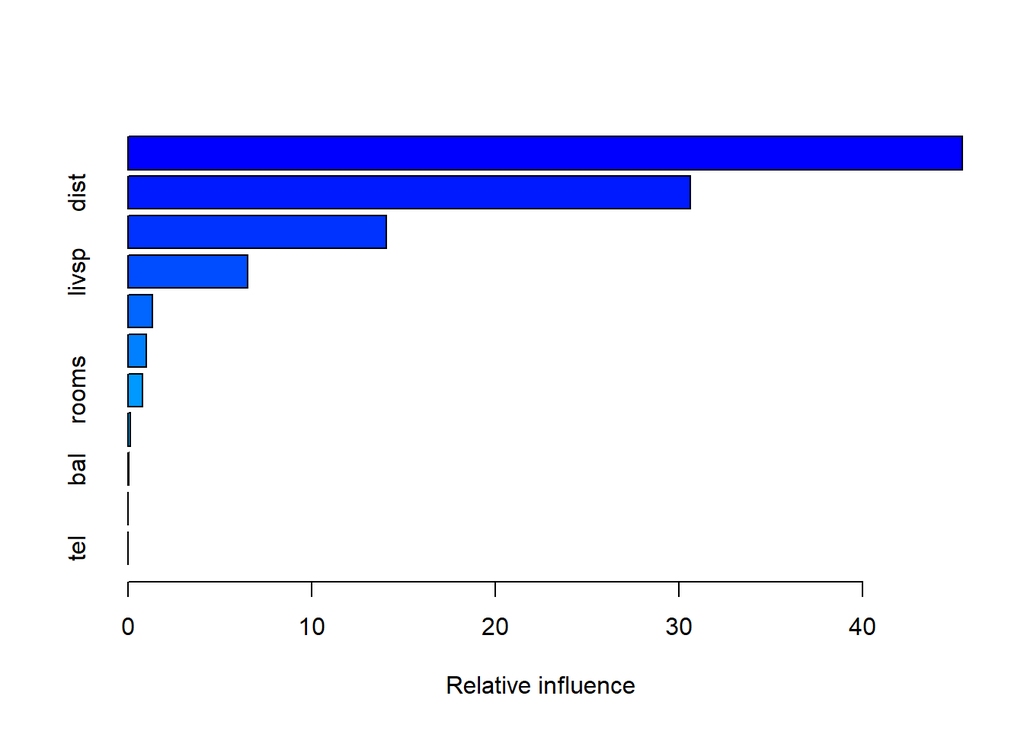

```
##               var     rel.inf
## price       price 45.44606477
## dist         dist 30.61897803
## kitsp       kitsp 14.07810390
## livsp       livsp  6.53339322
## totsp       totsp  1.34224873
## metrdist metrdist  1.01441912
## rooms       rooms  0.77704970
## walk         walk  0.13727331
## bal           bal  0.05246922
## floor       floor  0.00000000
## tel           tel  0.00000000
```

```r
set.seed(1)
boost.flats <- gbm(brick ~ ., data = flats.train.logical, distribution = "multinomial", n.trees = 360, shrinkage = 0.01)
summary(boost.flats)
```

В результате получается, что самыми значимыми являются признаки price, dist, kitsp и livsp.

Постоим матрицу несоответствия на тестовом наборе данных.

```r
boost.flats.test <- predict.gbm(boost.flats, newdata = flats.test.logical)
```

```
## Using 360 trees...
```

```r
labels <- flats.test.logical[,"brick"]
labels = colnames(boost.flats.test)[apply(boost.flats.test, 1, which.max)]
result = data.frame(flats.test.logical$brick, labels)
cmClassboost = table(as.factor(labels), flats.test.logical$brick)
cmClassboost
```

```
##
##       0   1
##   0 443 117
##   1  44 146
```

Вероятность правильной классификации.

```r
mean(flats.test.logical$brick == as.factor(labels))
```

```
## [1] 0.7853333
```

Вероятность попадания в нужный класс.

```r
diag(prop.table(cmClassboost, 2))
```

```
##         0         1
## 0.9096509 0.5551331
```

Таким образом, boosting модель на тестовом наборе данных смога правильно классифицировать квартиры, находящиеся не в кирпичных домах, с вероятностью примерно $90.96$%, а квартиры, которые, наоборот, находятся в кирпичных домах, с вероятностью $55.51$%. Общая вероятность правильной классификации составляет $78.53$%.